# Problem set 3

Author

In this assignment you will use U.S. Census data from the Current Population Survey Voter Supplement Files from 1972-2000 (excluding 1976) aggregated to the state level. The data file is on the course ELMS site and is named `aggcpsgvpt722.dta`. Please create a script file that shows your work and answer the questions below using the following information. Include the script file with your responses. Unless otherwise noted, you do not need to include tables or graphs of the results.

*Your script needs to run without errors. Please make sure to render it and look at the output before submitting it.*

**Dependent Variable**

- `vote`: defined as the turnout rate in a state in a given year (i.e. number who voted divided by the number eligible to vote).

**Independent Variables**

- `south`: a dummy variable equal to 1 for states from the confederacy and 0 otherwise.
- `pcthsg`: percentage of the population in a state that graduated high school (i.e. % that graduated high school only, as well as those who have more education).

*Be sure to look at the distributions of each of the variables. (On your own, but we should see that you did this in your code).*

```r
library("tidyverse")
```

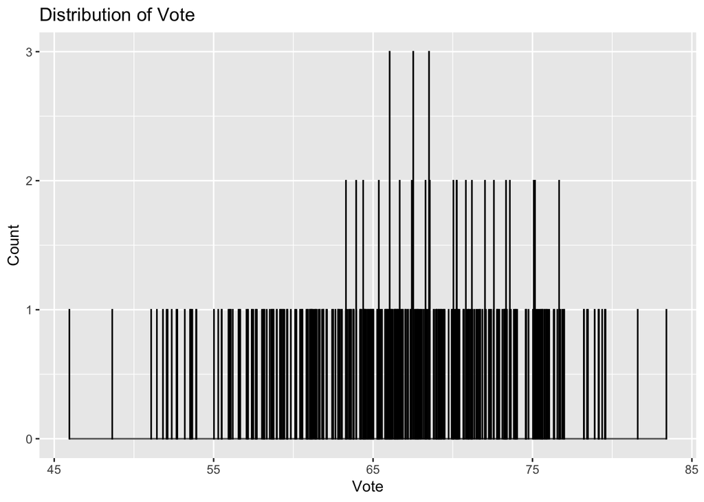

```r
library(ggplot2)
library(haven)

data <- read_dta("aggcpsgvpt722.dta")

ggplot(data, aes(x=vote)) +
  geom_histogram(binwidth=0.01, fill="blue", color="black") +
  labs(title="Distribution of Vote", x="Vote", y="Count")
```

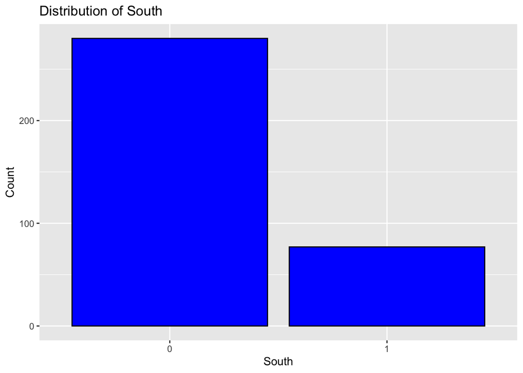

```r
ggplot(data, aes(x=factor(south))) +
  geom_bar(fill="blue", color="black") +
  labs(title="Distribution of South", x="South", y="Count")
```

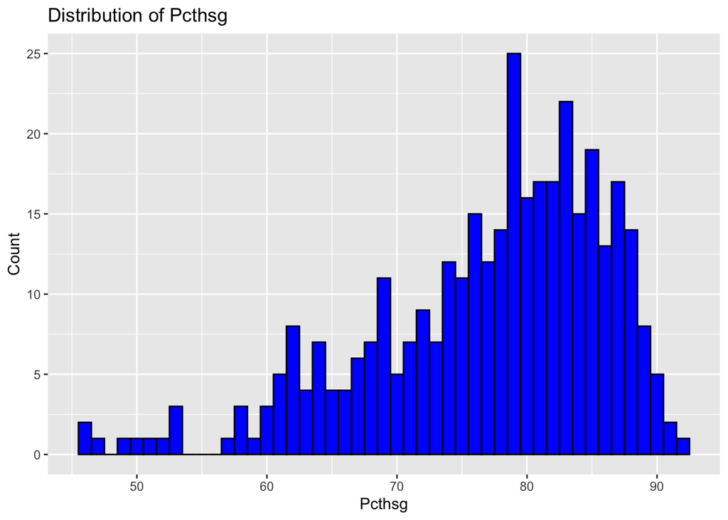

```r
ggplot(data, aes(x=pcthsg)) +
  geom_histogram(binwidth=1, fill="blue", color="black") +
  labs(title="Distribution of Pcthsg", x="Pcthsg", y="Count")
```

## Question 1

Using descriptive statistics only, what is the mean turnout rate in southern states? (1 point)

**Note**

1/1

**Answer:**

```r
uscensus <- haven::read_dta("aggcpsgvpt722.dta")


library(haven)

data <- read_dta("aggcpsgvpt722.dta")

south_states <- subset(data, south == 1)

mean_turnout_rate <- mean(south_states$vote, na.rm = TRUE)

print(mean_turnout_rate)
```

```
[1] 61.0675
```

## Question 2

Using descriptive statistics only, what is the mean turnout rate in non-southern states? (1 point)

**Note**

1/1

```r
mean_vote_non_south <- mean(data$vote[data$south == 0], na.rm = TRUE)

cat("Mean turnout rate in non-southern states:", mean_vote_non_south, "\n")
```

```
Mean turnout rate in non-southern states: 68.18086
```

## Question 3

Is the difference in mean turnout in southern vs. non-southern states **substantively significant**? That is, is the difference consequential to politics? Explain. Please confine your answer to no more than 2 sentences. (4 points)

**Note**

3/4

**Answer:**

**Note**

You need to make a call: significant or not. Then provide reasoning behind that call.

## Question 4

Using a difference of means test, is the difference statistically significant at $p<0.05$? (1 point)

**Note**

1/1

```r
t_test <- t.test(data$vote[data$south == 1], data$vote[data$south == 0])

cat("Independent Samples T-Test:\n")
```

```
Independent Samples T-Test:
```

```r
print(t_test)
```

```
    Welch Two Sample t-test

data:  data$vote[data$south == 1] and data$vote[data$south == 0]
t = -9.7728, df = 130.84, p-value < 2.2e-16
alternative hypothesis: true difference in means is not equal to 0
95 percent confidence interval:
 -8.553276 -5.673440
sample estimates:
mean of x mean of y
 61.06750  68.18086
```

**Answer:**

Yes, the difference of means test showed The p-value of the test is less than 2.2e−16, which is much smaller than 0.05. This means that we can reject the null hypothesis. Therefore, there is a significant difference in the means of between southern and non-southern states.

## Question 5

Run a regression with `vote` as the dependent variable and `south` as the independent variable. Is it meaningful to interpret the constant term on its own? If so, what information does it provide? Answer in one sentence. (2 points)

**Note**

1/2

```r
regression_model <- lm(vote ~ south, data=data)

summary(regression_model)
```

```
Call:
lm(formula = vote ~ south, data = data)

Residuals:
     Min       1Q   Median       3Q      Max
-22.2349  -3.6293   0.1373   4.3761  15.2183

Coefficients:
            Estimate Std. Error t value Pr(>|t|)
(Intercept)  68.1809     0.3565 191.239   <2e-16 ***
south        -7.1134     0.7677  -9.266   <2e-16 ***
---
Signif. codes:  0 '***' 0.001 '**' 0.01 '*' 0.05 '.' 0.1 ' ' 1

Residual standard error: 5.966 on 355 degrees of freedom
Multiple R-squared:  0.1948,    Adjusted R-squared:  0.1925
F-statistic: 85.86 on 1 and 355 DF,  p-value: < 2.2e-16
```

**Answer:**

The intercept (68.1809) on its own tell us the voter turn out rate of states outside of the south.

**Note**

The **average** voter turn out rate of states outside of the south.

## Question 6

Using the regression you just ran, in no more than one sentence interpret the **substantive meaning** of the coefficient on the `south` variable. (2 points)

**Note**

2/2

**Answer:**

The substantive meaning of the south coefficient means that on average a state located in the south has an average decrease of 7.11 voter turnout rate compared to states located else, provided we hold all else constant.

## Question 7

True or False. The results from the questions above indicate that the difference of means approach and the regression allow one to draw an identical set of conclusions? (1 point)

**Note**

0/1

**Answer:**

False, regression can only provide insights on relationships between variables but does not allow one to draw an identical set of conclusions.

## Question 8

Run a regression with `vote` as the dependent variable and `south` and `pcthsg` as the independent variables. Report the results in a professionally formatted table. Is it meaningful to interpret the constant term on its own? If so, what information does it provide? Answer in one sentence. (2 points)

**Note**

0/2

```r
library(stargazer)

data <- read_dta("aggcpsgvpt722.dta")

regression_model <- lm(vote ~ south + pcthsg, data=data)

stargazer(regression_model, type = "text", covariate.labels = c("Southern States", "Graduated High School"))
```

```
=================================================
                          Dependent variable:
                      ---------------------------
                                 vote
-------------------------------------------------
Southern States                -6.003***
                                (0.824)

Graduated High School          0.126***
                                (0.037)

Constant                       58.206***
                                (2.964)

-------------------------------------------------
Observations                      357
R2                               0.220
Adjusted R2                      0.216
Residual Std. Error        5.880 (df = 354)
F Statistic             49.943*** (df = 2; 354)
=================================================
Note:                 *p<0.1; **p<0.05; ***p<0.01
```

**Answer:**

**Note**

No, it indicates the predicted turn out rate among non-Southern states with a high school graduation rate of zero (which is impossible).

## Question 9

Compared to the regression you ran in *Question 5*, what happened to the coefficient on the `south` variable and why? Answer in no more than 2 sentences. (2 points)

**Note**

2/2

*Hint: take a look at the relationship between `south` and `pcthsg` (consider whether the `pcthsg` differs in the `south` vs. the `non-south`).*

```r
mean_southern <- mean(data$pcthsg[data$south == 1])

mean_non_southern <- mean(data$pcthsg[data$south == 0])

cat("Mean pcthsg in southern states:", round(mean_southern, 3), "\n")
```

```
Mean pcthsg in southern states: 70.135
```

```r
cat("Mean pcthsg in non-southern states:", round(mean_non_southern, 3), "\n")
```

```
Mean pcthsg in non-southern states: 78.921
```

**Answer:**

The coefficient decreased from -7.1134 to -6.003. The change can be attributed to the inclusion of the the pcthsg having some effect on the voter turnout rate in southern states.

## Question 10

Reflecting on all of the analyses you have run, is south, in the regression from *Question 5* exogenous? Why or why not? Answer in no more than one sentence. (1 point)

**Note**

1/1

**Answer:**

No, the south variable is not exogenous, as the coefficients change when additional variables are included which indicated potential correlation with unobserved factors and also raising concerns of an endogenous relationship.